# Analysis of US Brewery Market

Brychan Manry and Patricia Goresen

October 23, 2017

[Link to GitHub Repository](https://github.com/bmanry13/case_study_1)

```r
knitr::opts_chunk$set(echo = TRUE, message=FALSE)
```

# Introduction

The Company Hotshot Hops is creating a plan to expand their brewery across the nation. This analysis used datasets “beer.csv” and “breweries.csv” to look at different factors that may help determine the success Hopshot Hops may have in each state. To help with their planning Hotshot Hops has requested the following:

1. How many breweries are present in each state?
2. Merge data and print first and last six observations
3. How many missing values are in each column?
4. Compare median alcohol content (ABV) and international bitterness unit (IBU) by state
5. Compare maximum ABV and IBU by state
6. A summary of for the ABV values
7. Test the apparent relationship between IBU and ABV?

# Data Processing and Cleaning

The raw “beer.csv” and “breweries.csv” data sets provided by Hotshot Hops, where processed using the 8 steps below. Additional information regarding the cleaning process can be found in the [codebook](https://github.com/bmanry13/case_study_1/blob/master/rawdata/Codebook.md) as well in the data_processing.R located on the GitHub repository.

1. Read in Beer.csv and Breweries.csv
2. Remove Duplicate Observations from datasets
3. Remove unnecessary whitespace from values
4. Remove Extra Info inside of () from Beer and Brewery Names
5. Clean abbreviations and punctuations
6. Check for duplicates and Erroronius Breweries
7. Check for duplicates and Erroronius Beers
8. Merge datasets

*Map Shapefiles*: The map shapefiles were downloaded from the US States shapefiles data was acquired from the U.S. Census Bureau’s MAF/TIGER geographic database can be accessed at https://www.census.gov/geo/maps-data/.

# Analysis

## Q1: How many breweries are present in each state?

**State Brewery Count Reasoning:** More breweries means there will be more competition in that state.

*To address this question the dplyr package was used to: group the breweries by State, and then summaries by state the number of beweries within. Those state-level counts were then joined to the map shapefile data and run through the makeMap custom function which creates the map plot below. The source for the makeMap function can be found in the custom_functions.R source file in the analysis GitHub repository.*

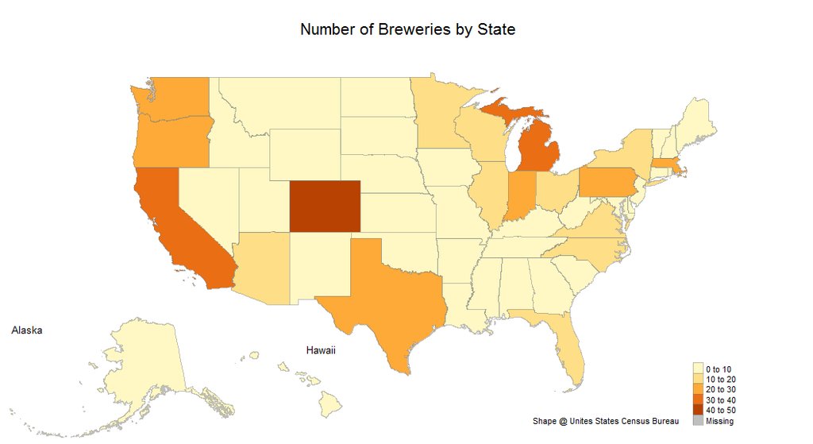

```r
usa.states.shape@data <- usa.states.shape@data %>%
  left_join(
    breweries %>% group_by(State) %>% summarise(n_breweries = n())
  )
makeMap(usa.states.shape,"n_breweries", "Number of Breweries by State")
```

The number of breweries in each state are shown in the table. The top five are Colorado with 47, California with 39, Michigan with 32, Oregon with 29 and Texas with 28. A full table of state brewery counts can be found at the bottom of this report

**State Brewery Count Conclusion:** Since Colorado has the most breweries, Hotshot Hops might not want to expand there.

## Q2: Merge data and print first and last six observations

*To merge the data, the breweries data frame was joined to the beers data frame using the merge() function. Then head and tail calls were piped to a kable() function to produce tables for the top and bottom 6 rows of the data.*

```r
beers <- merge(beers, breweries, by.x = "Brewery_id", by.y = "Brew_ID")
head(beers, n=6) %>% kable(row.names = FALSE, caption = "First Six Rows of Merged Data")
```

First Six Rows of Merged Data

| Brewery_id | Beer_Name | Beer_ID | ABV | IBU | Style | Ounces | Brewery_Name | City | State |
| --- | --- | --- | --- | --- | --- | --- | --- | --- | --- |
| 1 | Get Together | 2692 | 0.045 | 50 | American IPA | 16 | NorthGate Brewing | Minneapolis | MN |
| 1 | Maggie’s Leap | 2691 | 0.049 | 26 | Milk / Sweet Stout | 16 | NorthGate Brewing | Minneapolis | MN |
| 1 | Wall’s End | 2690 | 0.048 | 19 | English Brown Ale | 16 | NorthGate Brewing | Minneapolis | MN |
| 1 | Pumpion | 2689 | 0.060 | 38 | Pumpkin Ale | 16 | NorthGate Brewing | Minneapolis | MN |
| 1 | Stronghold | 2688 | 0.060 | 25 | American Porter | 16 | NorthGate Brewing | Minneapolis | MN |
| 1 | Parapet ESB | 2687 | 0.056 | 47 | Extra Special / Strong Bitter (ESB) | 16 | NorthGate Brewing | Minneapolis | MN |

```r
tail(beers,n=6) %>% kable(row.names = FALSE, caption = "Last Six Rows of Merged Data")
```

Last Six Rows of Merged Data

| Brewery_id | Beer_Name | Beer_ID | ABV | IBU | Style | Ounces | Brewery_Name | City | State |
| --- | --- | --- | --- | --- | --- | --- | --- | --- | --- |
| 556 | Pilsner Ukiah | 98 | 0.055 | NA | German Pilsener | 12 | Ukiah Brewing Company | Ukiah | CA |
| 557 | Heinnieweisse Weissebier | 52 | 0.049 | NA | Hefeweizen | 12 | Butternuts Beer and Ale | Garrattsville | NY |
| 557 | Snapperhead IPA | 51 | 0.068 | NA | American IPA | 12 | Butternuts Beer and Ale | Garrattsville | NY |
| 557 | Moo Thunder Stout | 50 | 0.049 | NA | Milk / Sweet Stout | 12 | Butternuts Beer and Ale | Garrattsville | NY |
| 557 | Porkslap Pale Ale | 49 | 0.043 | NA | American Pale Ale (APA) | 12 | Butternuts Beer and Ale | Garrattsville | NY |
| 558 | Urban Wilderness Pale Ale | 30 | 0.049 | NA | English Pale Ale | 12 | Sleeping Lady Brewing Company | Anchorage | AK |

The merged data is in a data frame called beers. The first six beers are Get Together, Maggie’s Leap, Wall’s End, Pumpion, Stronghold, and Parapet ESB. The last six beers are Pilsner Ukiah, Heinnieweisse Weissebier, Snapperhead IPA, Moo Thunder Stout, Porkslap Pale Ale, and Urban Wilderness Pale Ale.

## Q3: Report the number of NA’s in each column

*The colSums() function in conjunction with the is.na() function was used to calculate the number of missing values for each column.*

```r
colSums(is.na(beers))
```

```
##   Brewery_id    Beer_Name      Beer_ID          ABV          IBU
##            0            0            0           62          973
##        Style       Ounces Brewery_Name         City        State
##            5            0            0            0            0
```

## Q4: Compute the median alcohol content and international bitterness unit for each state. Plot a bar chart to compare

*To address this question the median ABV and IBU values were appended together then the medians for each were calculated using dplyr summaries(). The plot was created using ggplot with a facet grid to separate the ABV and IBU plots but while maintaining x-axis alignment.*

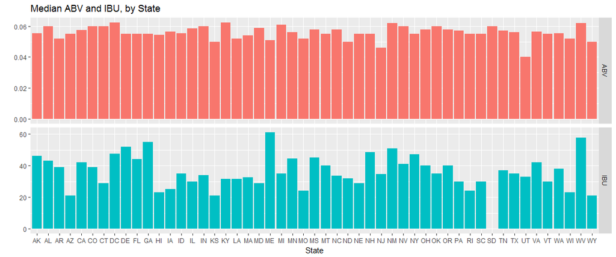

```r
# Median ABV and IBU by State Alpha
ggplot(
  bind_rows(
    beers %>% select(State, val = ABV) %>% mutate(var = "ABV"),
    beers %>% select(State, val = IBU) %>% mutate(var = "IBU")) %>%
    group_by(State, var) %>%
    summarise(med.val = median(val, na.rm = TRUE)),
  aes(x = State, fill = var, group = var)) +
  geom_bar(aes(y = med.val), stat = "identity",  position = "dodge", show.legend = FALSE) +
  facet_grid(var ~ ., scales = "free_y") +
  ylab("") +
  ggtitle("Median ABV and IBU, by State")
```

**State Median ABV Reasoning:** A low median alcohol content could suggest there are strict state laws against brewing beers with higher alcohol content.

*Similar to Q1 above the dplyr package to: group the breweries by State, and then summaries the median values for ABV and IBU. Those state-level values were then joined to the map shapefile data and run through the makeMap custom function.*

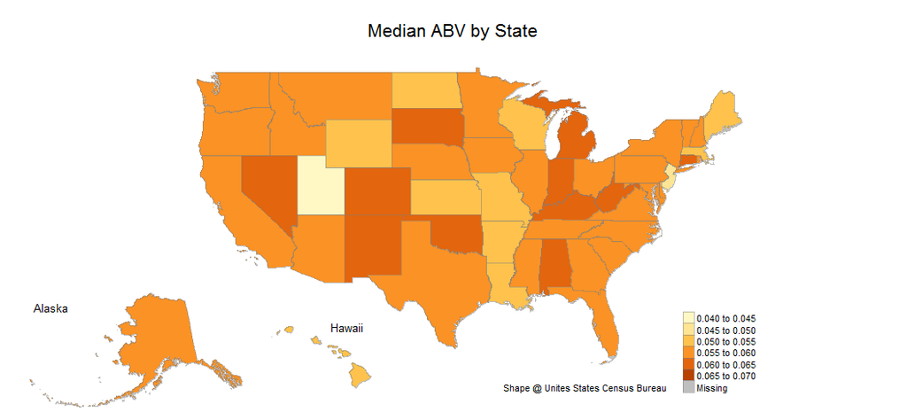

```r
usa.states.shape@data <- usa.states.shape@data %>%
  left_join(
    beers %>% group_by(State) %>% summarise(med_abv = median(ABV, na.rm = TRUE))
  )

makeMap(usa.states.shape, "med_abv", "Median ABV by State",seq(0.04,0.07,.005))
```

The states with the highest median ABV are the District of Columbia, Kentucky, Michigan, New Mexico, and West Virginia respectively.

**State Median IBU Reasoning:** Hotshot Hops’ beer has a relatively high international bitterness unit (IBU). As a result, Hotshot Hops want to expand in a state that is use to drinking beers with higher IBUs.

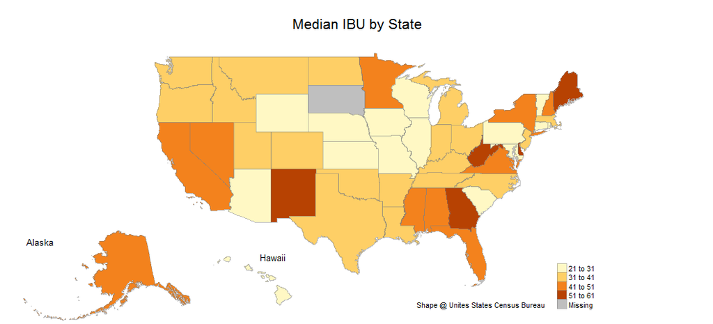

```r
usa.states.shape@data <- usa.states.shape@data %>%
  left_join(
    beers %>% group_by(State) %>% summarise(med_ibu = median(IBU, na.rm = TRUE))
  )
makeMap(usa.states.shape, "med_ibu", "Median IBU by State",seq(21,61,10))
```

## Q5: Which state has the maximum alcoholic beer? Which state has the most-bitter beer?

**Reasoning for State’s maximum ABV and IBU:** Similar to above, the state with the highest ABV is unlikely to implement strict ABV laws. Additionally, the states with the largest maximum IBU and ABV would indicate beers in the market similar to Hotshot Hops’s product lineup.

*Dplyr and summaries() were once again used to calculate max ABV and IBU by state. The results for each where then used to order the State variable factor levels so the ggplot bar plots would be ordered from highest to lowest.*

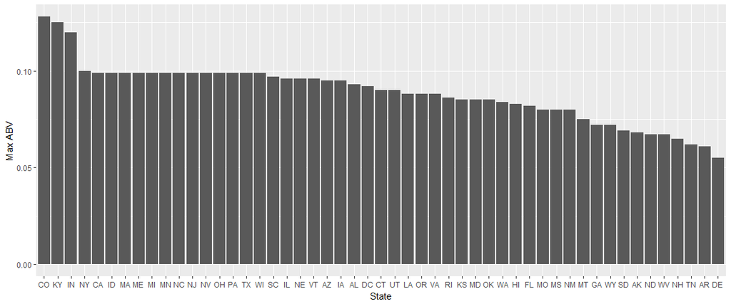

```r
# Median ABV by state - ordered by median
plot.df <- beers %>% group_by(State) %>% summarise(max.abv = max(ABV, na.rm = TRUE))
plot.df$State <- factor(plot.df$State, levels = plot.df$State[order(plot.df$max.abv, decreasing = TRUE)]) # orde states
ggplot(plot.df, aes(State, y = max.abv)) + geom_bar(stat = "identity") +
  ylab("Max ABV")
```

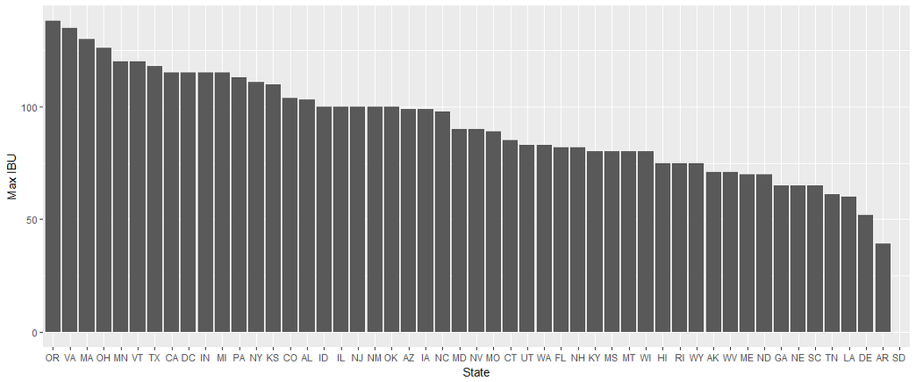

```r
# Median IBU by state - ordered by median
plot.df <- beers %>% group_by(State) %>% summarise(max.ibu = max(IBU, na.rm = TRUE))
plot.df$State <- factor(plot.df$State, levels = plot.df$State[order(plot.df$max.ibu, decreasing = TRUE)])
ggplot(plot.df, aes(State, y = max.ibu)) + geom_bar(stat = "identity") +
  ylab("Max IBU")
```

*To further assess the range of ABV and IBU values ggplot was used to plot individual points for each beer within each state.*

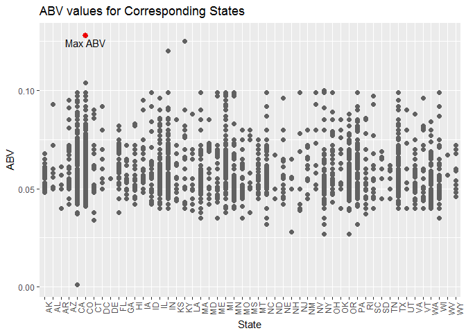

```r
#Maximum ABV of all States
MaxABV <- beers[which.max(beers$ABV),]
ggplot(beers, aes(x=State, y=ABV)) + geom_point(col="gray38", size=2) +geom_point(data=MaxABV, col="red2", size=2.5) + geom_text(data=MaxABV, label="Max ABV", vjust=1.4) + geom_segment(aes(x=State, xend= State, y=min(ABV), yend=max(ABV)), linetype="dashed", size=0.1) + labs(title= "ABV values for Corresponding States") + theme(axis.text.x=element_text(angle=90, hjust=1))
```

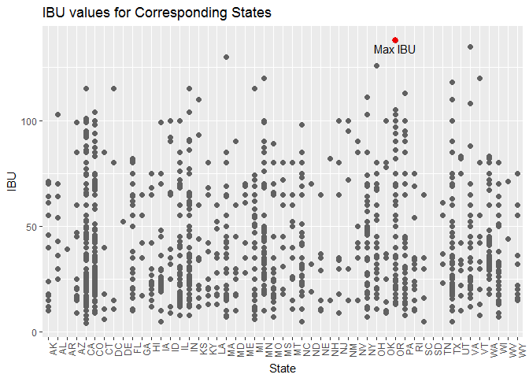

```r
#Maximum IBU of all States
MaxIBU <- beers[which.max(beers$IBU),]
ggplot(beers, aes(x=State, y=IBU)) + geom_point(col="gray38", size=2) +geom_point(data=MaxIBU, col="red2", size=2.5) + geom_text(data=MaxIBU, label="Max IBU", vjust=1.4) + geom_segment(aes(x=State, xend= State, y=min(IBU), yend=max(IBU)), linetype="dashed", size=0.1) + labs(title= "IBU values for Corresponding States") + theme(axis.text.x=element_text(angle=90, hjust=1))
```

**Conclusion for Max ABV and IBU:** The state that has the maximum ABV beer is Colorado. The state that has the most-bitter beer is Oregon. These would both be good candidates for expansion based on Hotshot Hops’ criteria.

## Q6: Summary statistics for the ABV

*A simple summary() call was used to calculate the summary stats for ABV.*

```r
summary(beers$ABV)
```

```
##    Min. 1st Qu.  Median    Mean 3rd Qu.    Max.    NA's
## 0.00100 0.05000 0.05600 0.05987 0.06800 0.12800      62
```

The mean for the ABV variable is 0.05987 and the median is 0.056. The first quartile is 0.05 and the third quartile is 0.068 and the values range from 0.001 to 0.128 with 62 NAs.

## Q7: Is there an apparent relationship between the bitterness of the beer and its alcoholic content?

*To create the plot for this question ggplot was used to make a point plot then add a linear smoothing line. The actual linear model was created with the lm() function then the results were formatted for use in html with pander().*

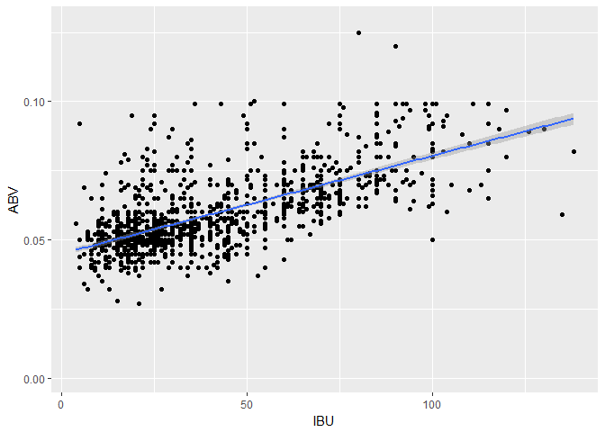

```r
ggplot(beers, aes(IBU, ABV))+
  geom_point() +
  geom_smooth(method = "lm")
```

```r
pander::pander(summary(lm(ABV ~ IBU, data = beers)))
```

|  | Estimate | Std. Error | t value | Pr(>\|t\|) |
| --- | --- | --- | --- | --- |
| **(Intercept)** | 0.04495 | 0.0005521 | 81.43 | 0 |
| **IBU** | 0.0003546 | 1.109e-05 | 31.98 | 6.111e-165 |

Fitting linear model: ABV ~ IBU

| Observations | Residual Std. Error | $R^2$ | Adjusted $R^2$ |
| --- | --- | --- | --- |
| 1267 | 0.01021 | 0.447 | 0.4466 |

# Conclusion

# Appendix

## State Count Table

This table was created by transforming the results of a table() call on the “State” column of the breweries data frame, then piping those results to the kable() function to make an html table.

```r
as.data.frame(table(breweries$State), responseName = "Number of Breweries") %>% rename(State = Var1) %>% kable()
```

| State | Number.of.Breweries |
| --- | --- |
| AK | 7 |
| AL | 3 |
| AR | 2 |
| AZ | 11 |
| CA | 39 |
| CO | 47 |
| CT | 8 |
| DC | 1 |
| DE | 2 |
| FL | 15 |
| GA | 7 |
| HI | 4 |
| IA | 5 |
| ID | 5 |
| IL | 18 |
| IN | 22 |
| KS | 3 |
| KY | 4 |
| LA | 5 |
| MA | 22 |
| MD | 7 |
| ME | 9 |
| MI | 32 |
| MN | 11 |
| MO | 9 |
| MS | 2 |
| MT | 9 |
| NC | 19 |
| ND | 1 |
| NE | 5 |
| NH | 3 |
| NJ | 3 |
| NM | 4 |
| NV | 2 |
| NY | 16 |
| OH | 15 |
| OK | 6 |
| OR | 29 |
| PA | 25 |
| RI | 5 |
| SC | 4 |
| SD | 1 |
| TN | 3 |
| TX | 28 |
| UT | 4 |
| VA | 15 |
| VT | 9 |
| WA | 23 |
| WI | 19 |
| WV | 1 |
| WY | 4 |